# Practical Machine Learning - Course Project

Pedro Ramírez (PowerChile)

February, 2015

### Overview

The goal of the course project was to predict the manner in which a set of persons did an exercise, i.e. the `classe` variable. For this purpose data from accelerometers on the belt, forearm, arm, and dumbell of 6 participants was used to create a prediction model using Machine Learning techniques.

The data used for this assignment comes from this source: http://groupware.les.inf.puc-rio.br/har

### Prediction model implementation & testing

#### Reading & filtering data

The input data was read first, and then it was filtered by discarding the features that were not relevant for the prediction. This was done to both, the data used to build the model, i.e. `DataModel`, and also the final test cases data, i.e. `FinalTest`.

```r
## Reading data from csv files
AUX_mod = read.csv('pml-training.csv', na.strings = 'NA', header = TRUE)    # Data for bulding/testing prediction model
AUX_fte = read.csv('pml-testing.csv' , na.strings = 'NA', header = TRUE)    # Final test cases data

## Removing data not required for the prediction model:
##   - NAs columns
##   - non-numerical columns (except 'classe')
##   - Other columns: 'X', 'raw_timestamp_part_1', 'raw_timestamp_part_2', and 'num_window'

# Searching columns to delete
colsNAs   <- colSums(is.na(AUX_fte)) == nrow(AUX_fte)
ColsNoNum <- !sapply(AUX_fte, is.numeric)
ColsOther <- names(AUX_fte) == 'X' | names(AUX_fte) == 'raw_timestamp_part_1' | names(AUX_fte) == 'raw_timestamp_part_2' | names(AUX_fte) == 'num_window'
cols2keep <- (colsNAs + ColsNoNum + ColsOther) == 0

# Deleting columns from data
DataModel <- AUX_mod[,cols2keep]    # Model data
FinalTest <- AUX_fte[,cols2keep]    # Final test cases data

# Getting rid of unused objects
rm(AUX_mod, AUX_fte, colsNAs, ColsNoNum, ColsOther, cols2keep)
```

#### Loading required packages & partitioning model’s training/testing data

The packages required to build the prediction models are loaded first [[1](http://cran.r-project.org/web/packages/caret/caret.pdf)], and then, the data required to implement the model was partitioned into a training and a testing dataset (75% and 25% respectively).

```r
## Loading required packages
library(lattice)
library(ggplot2)
library(caret)
library(foreach)
library(iterators)
library(parallel)
library(snow)
library(doSNOW)
set.seed(1852)

## Model data splitting into training/testing datasets
inTrain <- createDataPartition(y    = DataModel$classe,
                               p    = 0.75            ,
                               list = FALSE           )
training <- DataModel[ inTrain,]
testing  <- DataModel[-inTrain,]

# Getting rid of unused objects
rm(DataModel, inTrain)

# Enabling parallel processing to reduce computational time
cl <- makeCluster(detectCores() - 1, type = "SOCK")     # All cores except one
registerDoSNOW(cl)
```

```r
dim(training)
```

```
## [1] 14718    53
```

```r
dim(testing)
```

```
## [1] 4904   53
```

#### Models creation & comparison

Different models were trained and tested in order to find the model with the best performance. The models trained/tested were:

1. CART [[2](http://cran.r-project.org/web/packages/rpart/rpart.pdf)]
2. Random Forrest (RF) [[3](http://cran.r-project.org/web/packages/randomForest/randomForest.pdf)]
3. Linear Discriminant Analysis (LDA) [[4](http://cran.r-project.org/web/packages/lda/lda.pdf)]
4. Stochastic Gradient Boosting (GBM) [[5](http://cran.r-project.org/web/packages/gbm/gbm.pdf)]

##### Models creation

```r
## Models creation

# CART
if (!file.exists('ModFit_CART.RData')){
    ModFit_CART <- train(training$classe ~ .,
                         method = 'rpart'   ,
                         data   = training  )

    save(ModFit_CART, file = 'ModFit_CART.RData')
}else{
    load('ModFit_CART.RData')
}

# Random Forrest
if (!file.exists('ModFit_RF.RData')){
    ModFit_RF <- train(training$classe ~ .,
                       method = 'rf'      ,
                       data   = training  )

    save(ModFit_RF, file = 'ModFit_RF.RData')
}else{
    load('ModFit_RF.RData')
}

# Linear Discriminant Analysis
if (!file.exists('ModFit_LDA.RData')){
    ModFit_LDA <- train(training$classe ~ .,
                        method = 'lda'  ,
                        data   = training  )

    save(ModFit_LDA, file = 'ModFit_LDA.RData')
}else{
    load('ModFit_LDA.RData')
}

# Stochastic Gradient Boosting
if (!file.exists('ModFit_GBM.RData')){
    ModFit_GBM <- train(training$classe ~ .,
                        method = 'gbm'     ,
                        data   = training  )

    save(ModFit_GBM, file = 'ModFit_GBM.RData')
}else{
    load('ModFit_GBM.RData')
}
```

##### Models comparison

```r
## Models prediction accuracy calculation

# CART
acc_CART <- predict(ModFit_CART, testing)
CM_CART  <- confusionMatrix(testing$classe, acc_CART)

# Random Forrest
acc_RF <- predict(ModFit_RF, testing)
CM_RF  <- confusionMatrix(testing$classe, acc_RF)

# Linear Discriminant Analysis
acc_LDA <- predict(ModFit_LDA, testing)
CM_LDA  <- confusionMatrix(testing$classe, acc_LDA)

# Stochastic Gradient Boosting
acc_GBM <- predict(ModFit_GBM, testing)
CM_GBM  <- confusionMatrix(testing$classe, acc_GBM)


# Selecting model with an accuracy level above a threshold value
Accuracy <- c(CM_CART$overall[1], CM_RF$overall[1], CM_LDA$overall[1], CM_GBM$overall[1])
names(Accuracy) <- c('CART', 'RF', 'LDA', 'GBM')
Accuracy <- sort(Accuracy, decreasing = TRUE)
print(Accuracy)
```

```
##        RF       GBM       LDA      CART
## 0.9977569 0.9581974 0.7004486 0.4940865
```

```r
Threshold <- 0.9
SelectMod <- Accuracy[1:sum(Accuracy >= Threshold)]
print(SelectMod)
```

```
##        RF       GBM
## 0.9977569 0.9581974
```

```r
# Printing confusion matrix of selected models
for(i in 1:length(SelectMod)){
    print(paste('Confusion Matrix of model:',names(SelectMod[i]), sep = ' '))
    print(eval(parse(text = paste('CM_', names(SelectMod[i]), sep = ''))))
    cat('\n\n')
}
```

```
## [1] "Confusion Matrix of model: RF"
## Confusion Matrix and Statistics
##
##           Reference
## Prediction    A    B    C    D    E
##          A 1393    2    0    0    0
##          B    1  947    1    0    0
##          C    0    2  852    1    0
##          D    0    0    2  802    0
##          E    0    0    1    1  899
##
## Overall Statistics
##
##                Accuracy : 0.9978
##                  95% CI : (0.996, 0.9989)
##     No Information Rate : 0.2843
##     P-Value [Acc > NIR] : < 2.2e-16
##
##                   Kappa : 0.9972
##  Mcnemar's Test P-Value : NA
##
## Statistics by Class:
##
##                      Class: A Class: B Class: C Class: D Class: E
## Sensitivity            0.9993   0.9958   0.9953   0.9975   1.0000
## Specificity            0.9994   0.9995   0.9993   0.9995   0.9995
## Pos Pred Value         0.9986   0.9979   0.9965   0.9975   0.9978
## Neg Pred Value         0.9997   0.9990   0.9990   0.9995   1.0000
## Prevalence             0.2843   0.1939   0.1746   0.1639   0.1833
## Detection Rate         0.2841   0.1931   0.1737   0.1635   0.1833
## Detection Prevalence   0.2845   0.1935   0.1743   0.1639   0.1837
## Balanced Accuracy      0.9994   0.9976   0.9973   0.9985   0.9998
##
##
## [1] "Confusion Matrix of model: GBM"
## Confusion Matrix and Statistics
##
##           Reference
## Prediction    A    B    C    D    E
##          A 1370   18    5    1    1
```

[output cut: 11 more lines]

```
##
##                   Kappa : 0.9471
##  Mcnemar's Test P-Value : 0.001137
##
## Statistics by Class:
##
##                      Class: A Class: B Class: C Class: D Class: E
## Sensitivity            0.9779   0.9384   0.9189   0.9599   0.9863
## Specificity            0.9929   0.9833   0.9903   0.9907   0.9908
## Pos Pred Value         0.9821   0.9305   0.9544   0.9527   0.9589
## Neg Pred Value         0.9912   0.9853   0.9822   0.9922   0.9970
## Prevalence             0.2857   0.1919   0.1811   0.1627   0.1786
## Detection Rate         0.2794   0.1801   0.1664   0.1562   0.1762
## Detection Prevalence   0.2845   0.1935   0.1743   0.1639   0.1837
## Balanced Accuracy      0.9854   0.9609   0.9546   0.9753   0.9886
```

From the list of models trained and tested, only the models with an accuracy level equal or larger than 90% were analyzed. The best performance was achieved by the **Random Forrest** model (Model RF) with an accuracy level of **99.78%**, followed by the Stochastic Gradient Boosting model (Model GBM) with an accuracy level of 95.82%.

#### Model cross-validation & out-of-sample error

##### Cross-validation

As it was analized in the previous section, the **Model RF** outperformed all other models, and was selected for further analysis and for the final prediction task. In order to cross-validate the model, and also avoid overfitting, a 10-fold cross-validation with 5 times repetition was performed to train the model.

```r
## Model RF_cv - Cross-validation
if (!file.exists('ModFit_RF_cv.RData')){
    set.seed(1852)
    trainCtrl    <- trainControl(method  = 'repeatedcv',
                                 number  = 10          ,
                                 repeats = 5           )
    ModFit_RF_cv <- train(training$classe ~ .   ,
                           method    = 'rf'     ,
                           data      = training ,
                           trControl = trainCtrl)
    save(ModFit_RF_cv, file = 'ModFit_RF_cv.RData')
}else{
    load('ModFit_RF_cv.RData')
}
print(ModFit_RF_cv)
```

```
## Random Forest
##
## 14718 samples
##    52 predictor
##     5 classes: 'A', 'B', 'C', 'D', 'E'
##
## No pre-processing
## Resampling: Cross-Validated (10 fold, repeated 5 times)
##
## Summary of sample sizes: 13248, 13246, 13245, 13246, 13246, 13248, ...
##
## Resampling results across tuning parameters:
##
##   mtry  Accuracy   Kappa      Accuracy SD  Kappa SD
##    2    0.9923635  0.9903392  0.002131018  0.002696408
##   27    0.9927028  0.9907684  0.002450483  0.003100217
##   52    0.9881780  0.9850429  0.003335634  0.004221582
##
## Accuracy was used to select the optimal model using  the largest value.
## The final value used for the model was mtry = 27.
```

```r
# Model RF_cv - Prediction accuracy calculation
acc_RF_cv <- predict(ModFit_RF_cv, testing)
CM_RF_cv  <- confusionMatrix(testing$classe, acc_RF_cv)
print(CM_RF_cv)
```

```
## Confusion Matrix and Statistics
##
##           Reference
## Prediction    A    B    C    D    E
##          A 1391    3    0    0    1
##          B    1  946    2    0    0
##          C    0    4  848    3    0
##          D    0    1    6  796    1
##          E    0    0    1    1  899
##
## Overall Statistics
##
##                Accuracy : 0.9951
##                  95% CI : (0.9927, 0.9969)
##     No Information Rate : 0.2838
##     P-Value [Acc > NIR] : < 2.2e-16
##
##                   Kappa : 0.9938
##  Mcnemar's Test P-Value : NA
##
## Statistics by Class:
##
##                      Class: A Class: B Class: C Class: D Class: E
## Sensitivity            0.9993   0.9916   0.9895   0.9950   0.9978
## Specificity            0.9989   0.9992   0.9983   0.9981   0.9995
## Pos Pred Value         0.9971   0.9968   0.9918   0.9900   0.9978
## Neg Pred Value         0.9997   0.9980   0.9978   0.9990   0.9995
## Prevalence             0.2838   0.1945   0.1748   0.1631   0.1837
## Detection Rate         0.2836   0.1929   0.1729   0.1623   0.1833
## Detection Prevalence   0.2845   0.1935   0.1743   0.1639   0.1837
## Balanced Accuracy      0.9991   0.9954   0.9939   0.9965   0.9986
```

After performing the cross-validation, the accuracy of the Random Forrest with cross-validation model (Model RF_cv) was **99.51%**, which is approximately the same as before. The difference observed in the accuracy is due to the first time the Model RF was trained using bootstrap, which underestimates the error [[6](https://d396qusza40orc.cloudfront.net/predmachlearn/008crossValidation.pdf)].

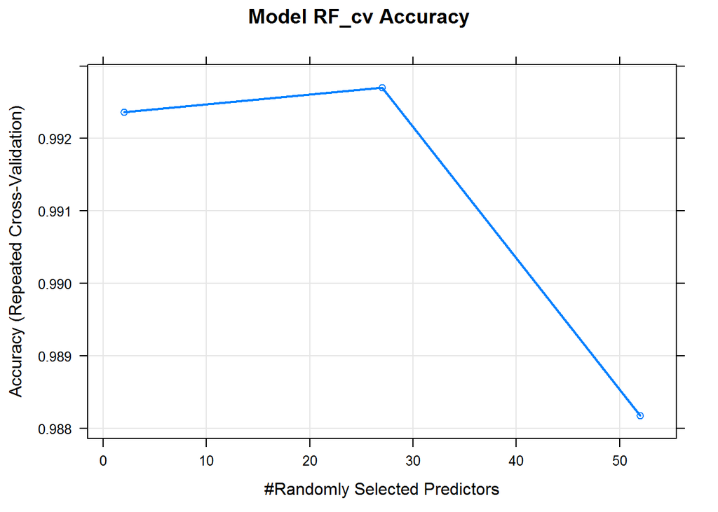

```r
#  Model RF_cv - Accuracy plot
plot(ModFit_RF_cv, lwd = 2, main = 'Model RF_cv Accuracy')
```

The most important predictor for the Model RF_cv is the `roll_belt` variable, as shown in the figure below.

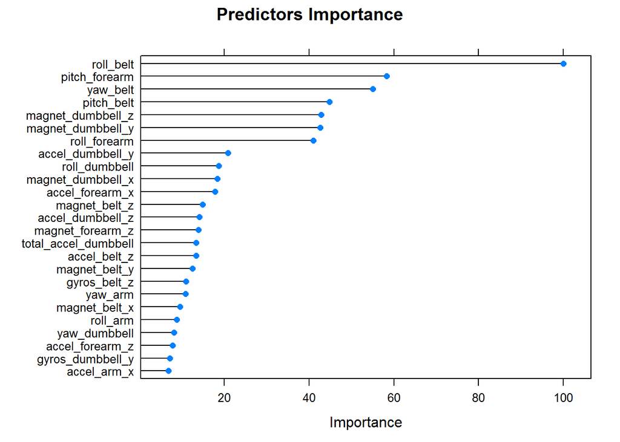

```r
# Model RF_cv - Predictors importance
plot(varImp(ModFit_RF_cv, scale = TRUE), top = 25, lwd = 2, main = 'Predictors Importance')
```

##### Out-of-sample error

The out-of-sample error of the Model RF_cv was estimated to be **0.49%**.

```r
## Model RF_c - Out-of-sample error
OutOfSampleError <- 100*(1 - CM_RF_cv$overall[1])
paste0('Out-of-sample error estimation Model RF: ', round(OutOfSampleError, digits = 2), '%')
```

```
## [1] "Out-of-sample error estimation Model RF: 0.49%"
```

### Test cases results

Applying the Model RF_cv to the final test data, i.e. `FinalTest`, the predictions for each test case were as follows:

```r
## Model RF_cv - Prediction for test cases
prediction_TestCases <-predict(ModFit_RF_cv, FinalTest[,-53])
print(prediction_TestCases)
```

```
##  [1] B A B A A E D B A A B C B A E E A B B B
## Levels: A B C D E
```

Finally, the prediction results were written each into a text final for final submission.

```r
## Model RF_cv - Final submission text files creation
pml_write_files = function(x){
  n = length(x)
  for(i in 1:n){
    filename = paste0("problem_id_",i,".txt")
    write.table(x[i], file = filename, quote = FALSE, row.names = FALSE, col.names = FALSE)
  }
}

pml_write_files(as.character(prediction_TestCases))
```